# GSE98923 co-expression analysis

CEMiTool baseline - 54-sample balanced design

2026-09-21

# 1 Scope

This report documents the computational analysis of the balanced 54-sample subset of GEO accession **GSE98923** used in the CEMiTool baseline workflow.

The report is intended as an analysis record and potential supplementary document for a scientific manuscript. Large machine-readable matrices are not printed in full in the document; complete files are preserved separately and indexed in the supplementary manifest.

# 2 Experimental design

The analysis contains **54 samples**, covering two cultivars, three developmental stages, three years, and three biological replicates per cultivar-stage-year combination.

Sample counts by cultivar, developmental stage, and year.

| Cultivar | Stage | Year | Freq |
| --- | --- | --- | --- |
| Cabernet Sauvignon | FruitSet | 2012 | 3 |
| Pinot noir | FruitSet | 2012 | 3 |
| Cabernet Sauvignon | Harvest | 2012 | 3 |
| Pinot noir | Harvest | 2012 | 3 |
| Cabernet Sauvignon | Veraison | 2012 | 3 |
| Pinot noir | Veraison | 2012 | 3 |
| Cabernet Sauvignon | FruitSet | 2013 | 3 |
| Pinot noir | FruitSet | 2013 | 3 |
| Cabernet Sauvignon | Harvest | 2013 | 3 |
| Pinot noir | Harvest | 2013 | 3 |
| Cabernet Sauvignon | Veraison | 2013 | 3 |
| Pinot noir | Veraison | 2013 | 3 |
| Cabernet Sauvignon | FruitSet | 2014 | 3 |
| Pinot noir | FruitSet | 2014 | 3 |
| Cabernet Sauvignon | Harvest | 2014 | 3 |
| Pinot noir | Harvest | 2014 | 3 |
| Cabernet Sauvignon | Veraison | 2014 | 3 |
| Pinot noir | Veraison | 2014 | 3 |

# 3 Expression data

The processed matrix used for CEMiTool contains **29971 genes** and **54 samples**.

Expression values were derived from the processed RPKM matrix distributed with GSE98923 and transformed as:

$$\log_2(\mathrm{RPKM} + 1)$$

The complete matrices are available under:

- `data/processed/expression_rpkm.tsv`
- `data/processed/expression_log2rpkm.tsv`

# 4 CEMiTool analysis

CEMiTool identified **11 modules** in the baseline analysis.

The analysis used Pearson correlation, an unsigned network, a signed TOM, a minimum module size of 30, and a fixed random seed of 1234.

Automatic beta selection did not identify a usable value in the initial baseline run. To reproduce the established 54-sample baseline, the soft-thresholding power was fixed explicitly at **beta = 10** using `set_beta = 10` and `force_beta = FALSE`. This value is specific to the present expression matrix and should be re-evaluated if the sample set, normalization, or filtering changes. The recorded beta for this run is **10**.

Recorded analysis parameters.

| parameter | value |
| --- | --- |
| dataset | GSE98923 |
| samples | 54 |
| transform | log2(RPKM+1) |
| correlation | pearson |
| network_type | unsigned |
| tom_type | signed |
| beta_strategy | manual_set_beta_beta10 |
| set_beta | 10 |
| force_beta | FALSE |
| beta | 10 |
| r2 | 0.706374247063269 |
| filter | TRUE |
| filter_pval | 0.1 |
| min_module_size | 30 |
| seed | 1234 |
| modules | 11 |

# 5 Diagnostic and analysis figures

All figures generated by the analysis are stored in `results/figures/`. PDF figures are converted to PNG copies for reliable inclusion in Word and HTML reports.

## 5.1 beta_r2

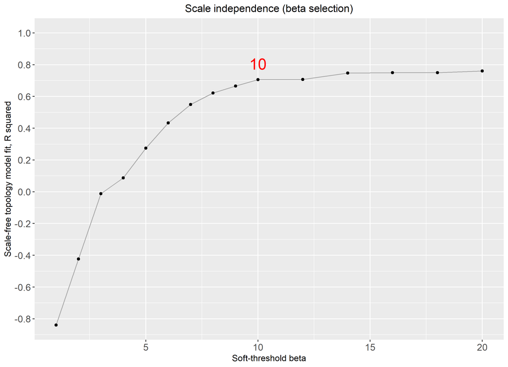

## 5.2 gsea

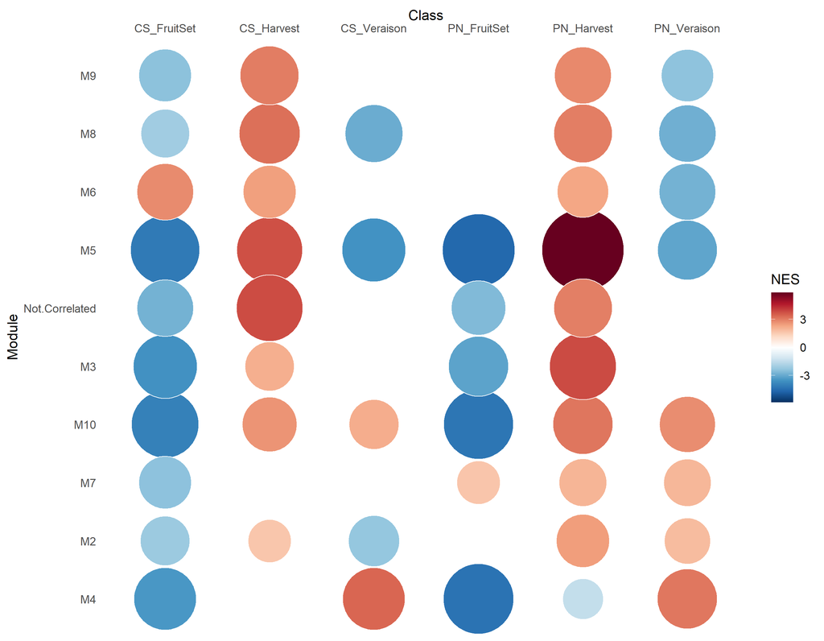

## 5.3 hist

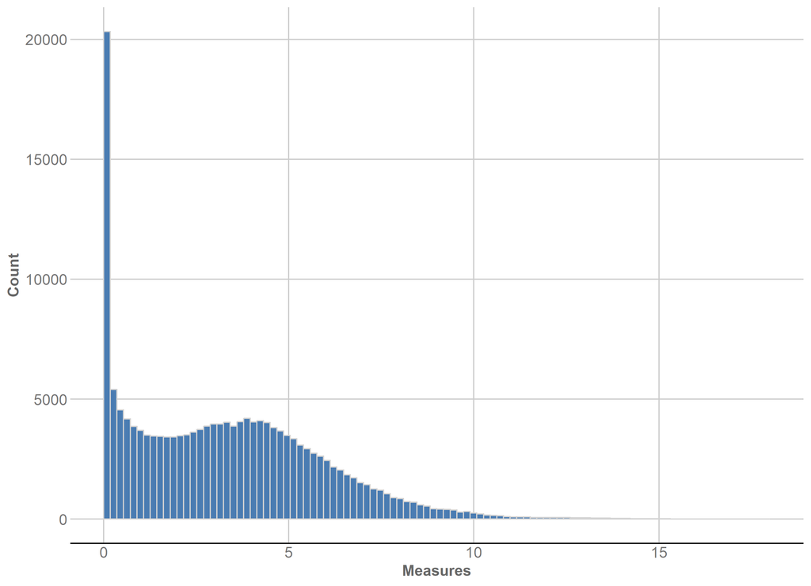

## 5.4 mean_k

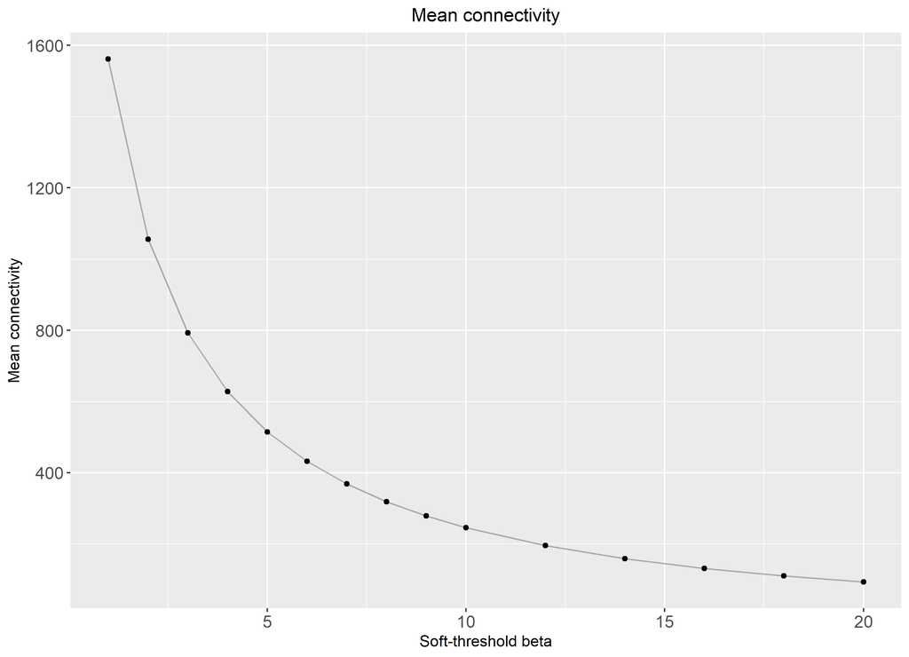

## 5.5 mean_var

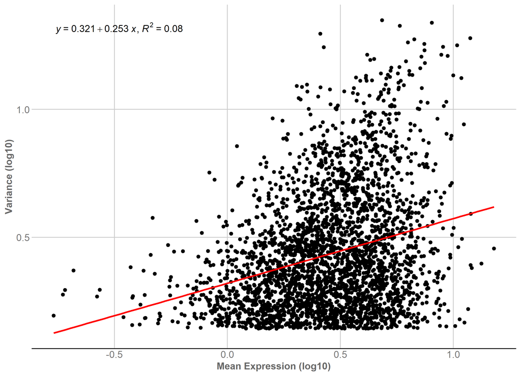

## 5.6 profile_M1

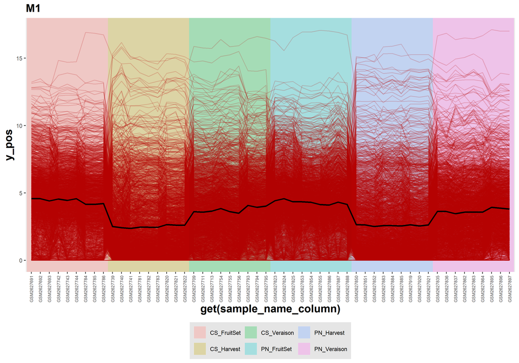

## 5.7 profile_M10

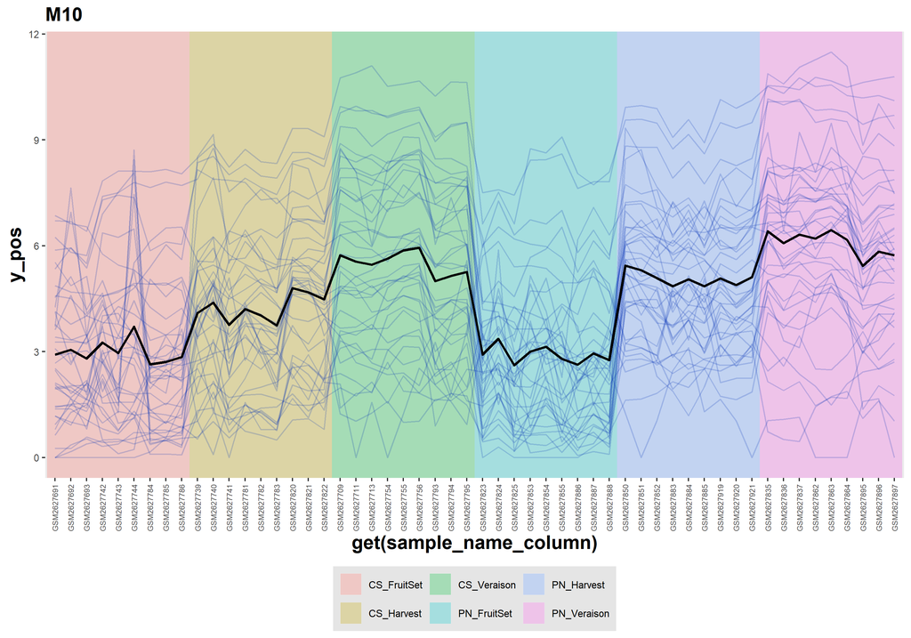

## 5.8 profile_M2

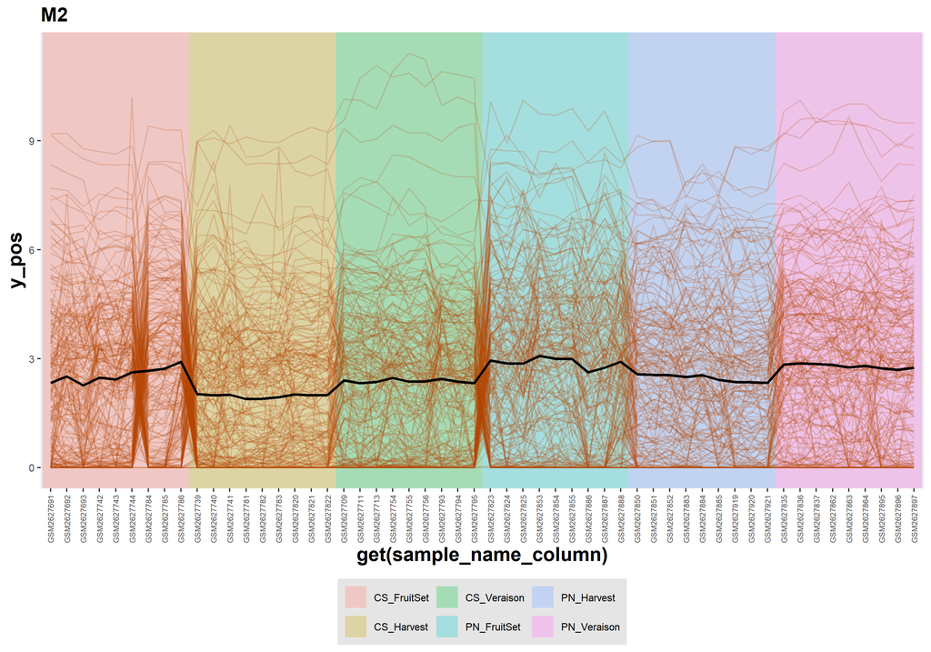

## 5.9 profile_M3

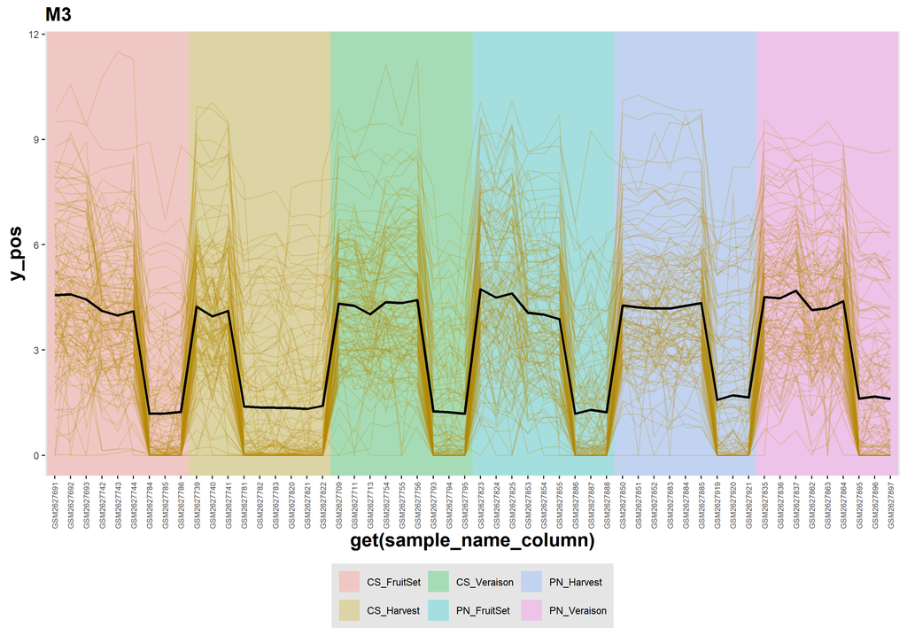

## 5.10 profile_M4

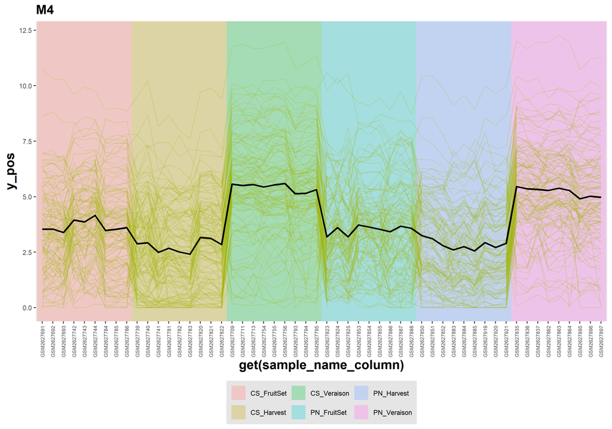

## 5.11 profile_M5

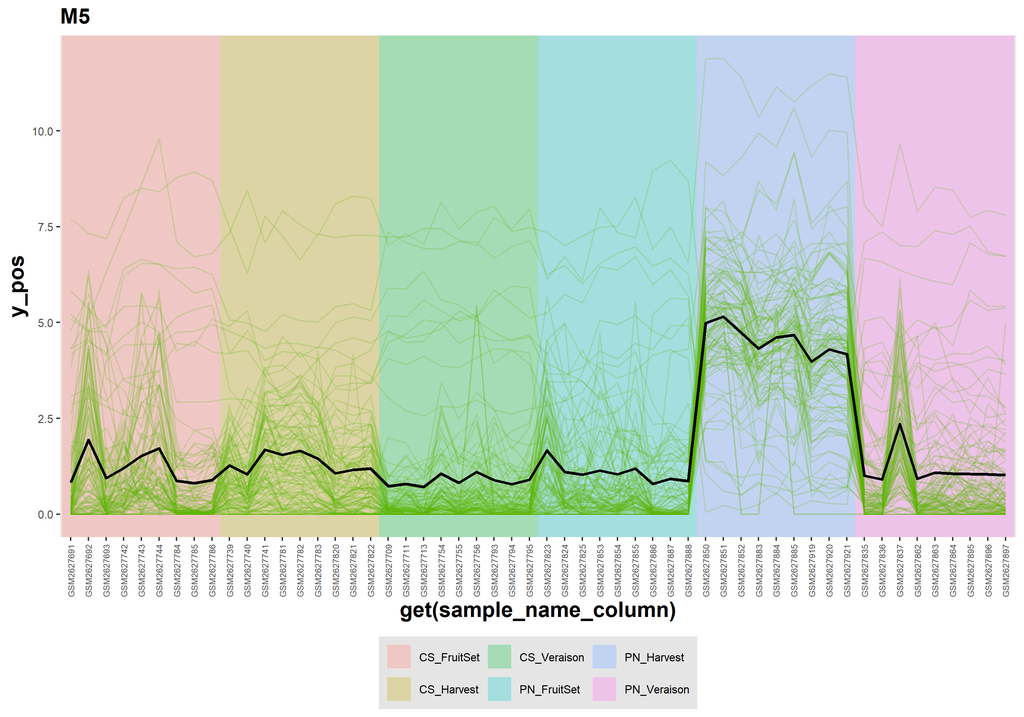

## 5.12 profile_M6

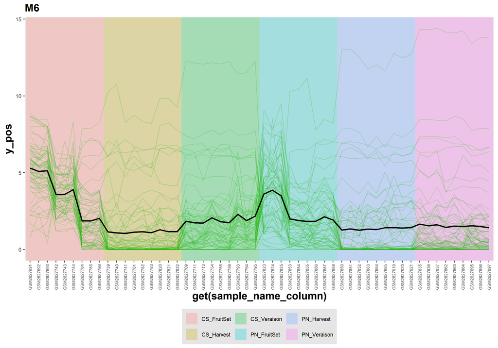

## 5.13 profile_M7

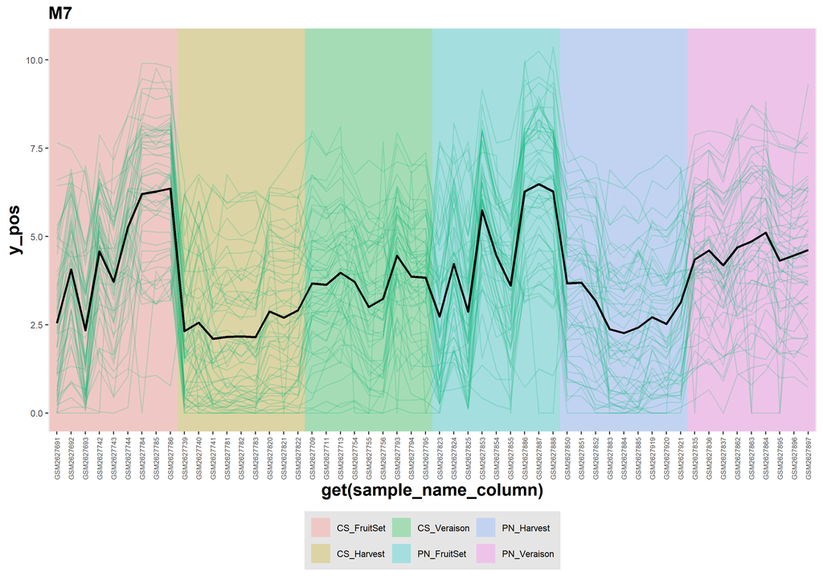

## 5.14 profile_M8

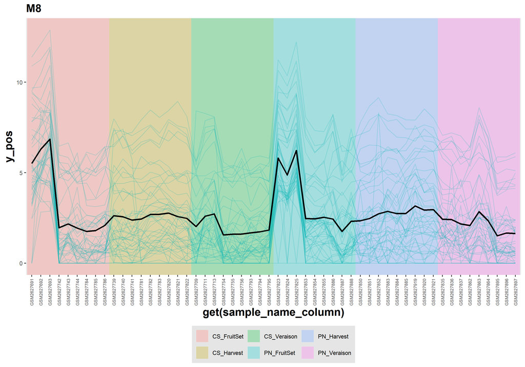

## 5.15 profile_M9

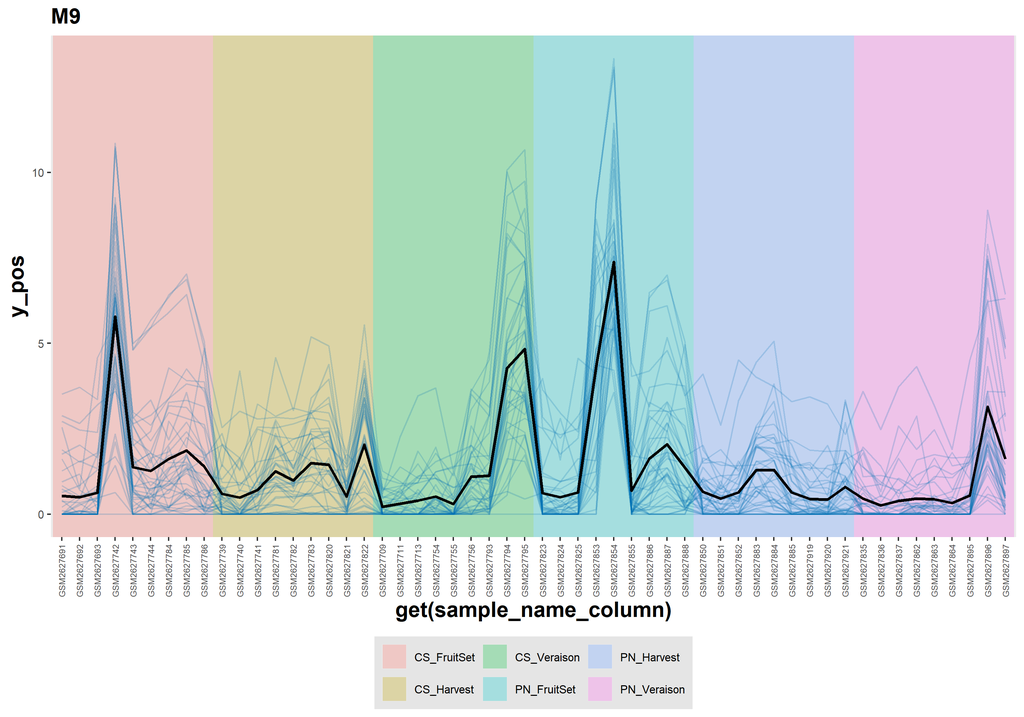

## 5.16 profile_Not_Correlated

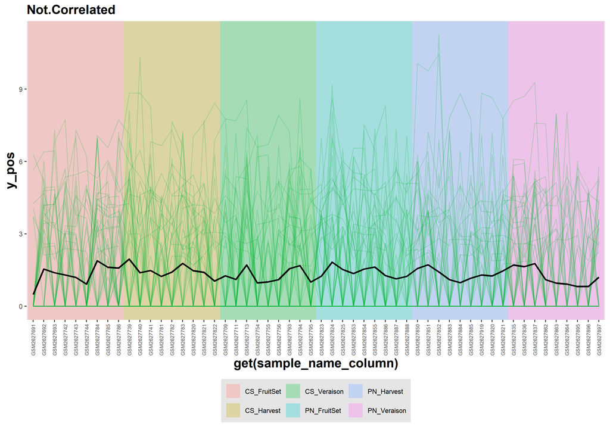

## 5.17 qq

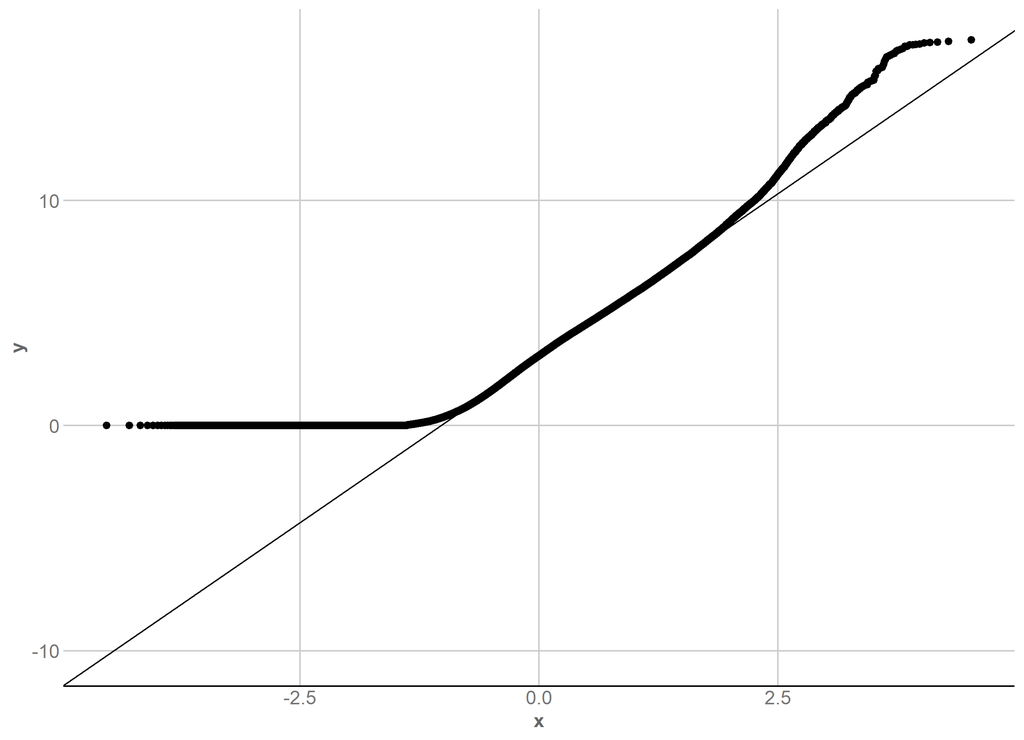

# 6 Exported result tables

The following section provides a compact view of every tabular result exported by CEMiTool. Complete tables remain available as machine-readable files under `results/tables/`.

## 6.1 beta_fit_indices.tsv

Dimensions: 15 rows x 10 columns.

beta_fit_indices.tsv

| Power | SFT.R.sq | slope | truncated.R.sq | mean.k. | median.k. | max.k. | Density | Centralization | Heterogeneity |
| --- | --- | --- | --- | --- | --- | --- | --- | --- | --- |
| 1 | 0.8394009 | 1.5707687 | 0.7946939 | 1561.85711 | 1754.66121 | 2111.9801 | 0.5122523 | 0.1805457 | 0.3207976 |
| 2 | 0.4232012 | 0.3873307 | 0.5948254 | 1055.58487 | 1206.78781 | 1705.7211 | 0.3462069 | 0.2133693 | 0.4790910 |
| 3 | 0.0123211 | 0.0444688 | 0.7254709 | 792.10695 | 884.92845 | 1453.8582 | 0.2597924 | 0.2171812 | 0.5801171 |
| 4 | 0.0875404 | -0.1174076 | 0.8310439 | 627.73973 | 675.70175 | 1274.2760 | 0.2058838 | 0.2121878 | 0.6544427 |
| 5 | 0.2744513 | -0.2192085 | 0.8129080 | 514.61128 | 528.42690 | 1136.6584 | 0.1687803 | 0.2041506 | 0.7137761 |
| 6 | 0.4333524 | -0.3044837 | 0.7362054 | 431.82894 | 421.50854 | 1026.4451 | 0.1416297 | 0.1951480 | 0.7635877 |
| 7 | 0.5495793 | -0.3627214 | 0.6942176 | 368.65752 | 339.87135 | 935.4799 | 0.1209110 | 0.1860264 | 0.8068294 |
| 8 | 0.6217077 | -0.4267637 | 0.6648029 | 318.95073 | 277.02872 | 858.7238 | 0.1046083 | 0.1771490 | 0.8452677 |
| 9 | 0.6650263 | -0.4781301 | 0.6414873 | 278.90991 | 228.17373 | 792.8474 | 0.0914759 | 0.1686699 | 0.8800415 |
| 10 | 0.7063742 | -0.5251829 | 0.6502824 | 246.04985 | 189.37337 | 735.5400 | 0.0806985 | 0.1606465 | 0.9119266 |
| 12 | 0.7067470 | -0.6147726 | 0.6230659 | 195.57118 | 134.48070 | 640.3966 | 0.0641427 | 0.1459880 | 0.9690884 |
| 14 | 0.7472853 | -0.6734742 | 0.6797739 | 158.91923 | 97.11593 | 564.3466 | 0.0521218 | 0.1330578 | 1.0196729 |
| 16 | 0.7496827 | -0.7344417 | 0.6990696 | 131.36780 | 72.38920 | 502.0230 | 0.0430855 | 0.1216459 | 1.0654044 |
| 18 | 0.7495778 | -0.7871557 | 0.7234977 | 110.09929 | 53.69994 | 449.9688 | 0.0361100 | 0.1115423 | 1.1073859 |
| 20 | 0.7605758 | -0.8268108 | 0.7500230 | 93.33028 | 40.81002 | 405.8351 | 0.0306101 | 0.1025615 | 1.1463678 |

## 6.2 enrichment_es.tsv

Dimensions: 10 rows x 7 columns.

enrichment_es.tsv

| pathway | CS_FruitSet | CS_Veraison | CS_Harvest | PN_FruitSet | PN_Veraison | PN_Harvest |
| --- | --- | --- | --- | --- | --- | --- |
| M10 | -0.7230231 | 0.5985374 | 0.4662943 | -0.7631498 | 0.7632057 | 0.5953022 |
| M2 | -0.2702467 | -0.4045229 | 0.1897572 | 0.1528338 | 0.4009491 | 0.3168241 |
| M3 | -0.4928964 | -0.0775830 | 0.2777637 | -0.4016256 | 0.2979030 | 0.5528034 |
| M4 | -0.4797068 | 0.7662442 | -0.2166083 | -0.5704144 | 0.7178583 | -0.2388118 |
| M5 | -0.5946456 | -0.6852390 | 0.5099956 | -0.6279539 | -0.5903679 | 0.8708191 |
| M6 | 0.5981419 | -0.2428080 | 0.3700474 | 0.1467911 | -0.5620152 | 0.3800916 |
| M7 | -0.4028705 | -0.2620536 | -0.2969209 | 0.3406279 | 0.5067387 | 0.3471849 |
| M8 | -0.3513185 | -0.6778466 | 0.5233773 | 0.3072853 | -0.6231626 | 0.5444628 |
| M9 | -0.4249585 | -0.1595745 | 0.5184045 | 0.3130987 | -0.5479842 | 0.5255984 |
| Not.Correlated | -0.4570197 | -0.1856715 | 0.6155754 | -0.4134418 | -0.2873009 | 0.5145339 |

## 6.3 enrichment_nes.tsv

Dimensions: 10 rows x 7 columns.

enrichment_nes.tsv

| pathway | CS_FruitSet | CS_Veraison | CS_Harvest | PN_FruitSet | PN_Veraison | PN_Harvest |
| --- | --- | --- | --- | --- | --- | --- |
| M10 | -3.959396 | 2.1492587 | 2.615432 | -4.2536734 | 2.728041 | 3.118858 |
| M2 | -2.141531 | -2.2761001 | 1.614254 | 0.9429160 | 1.839075 | 2.451360 |
| M3 | -3.541564 | -0.4093924 | 2.099724 | -3.1346970 | 1.304286 | 3.856798 |
| M4 | -3.403567 | 3.3899077 | -1.230025 | -4.3302647 | 3.115328 | -1.424578 |
| M5 | -4.156126 | -3.5193848 | 3.767544 | -4.5950476 | -3.083399 | 5.848706 |
| M6 | 2.777735 | -1.1341715 | 2.424789 | 0.7430314 | -2.774107 | 2.283311 |
| M7 | -2.394055 | -1.1530162 | -1.444617 | 1.6434296 | 1.941217 | 1.979208 |
| M8 | -2.044511 | -2.9146050 | 3.236747 | 1.4406157 | -2.837919 | 2.984385 |
| M9 | -2.405142 | -0.6670530 | 3.002033 | 1.4350954 | -2.385699 | 2.803384 |
| Not.Correlated | -2.773385 | -0.8343909 | 3.831869 | -2.5856587 | -1.359322 | 2.973914 |

## 6.4 enrichment_padj.tsv

Dimensions: 10 rows x 7 columns.

enrichment_padj.tsv

| pathway | CS_FruitSet | CS_Veraison | CS_Harvest | PN_FruitSet | PN_Veraison | PN_Harvest |
| --- | --- | --- | --- | --- | --- | --- |
| M10 | 0.0000000 | 0.0000225 | 0.0000024 | 0.0000000 | 0.0000000 | 0.0000000 |
| M2 | 0.0000000 | 0.0000000 | 0.0004024 | 0.6718346 | 0.0000035 | 0.0000000 |
| M3 | 0.0000000 | 1.0000000 | 0.0000024 | 0.0000000 | 0.0774487 | 0.0000000 |
| M4 | 0.0000000 | 0.0000000 | 0.1552106 | 0.0000000 | 0.0000000 | 0.0377113 |
| M5 | 0.0000000 | 0.0000000 | 0.0000000 | 0.0000000 | 0.0000000 | 0.0000000 |
| M6 | 0.0000000 | 0.3151261 | 0.0000022 | 0.8589894 | 0.0000000 | 0.0000089 |
| M7 | 0.0000037 | 0.3151261 | 0.0707547 | 0.0165577 | 0.0001668 | 0.0011522 |
| M8 | 0.0002388 | 0.0000000 | 0.0000000 | 0.0829238 | 0.0000000 | 0.0000000 |
| M9 | 0.0000254 | 1.0000000 | 0.0000000 | 0.0829238 | 0.0000047 | 0.0000001 |
| Not.Correlated | 0.0000000 | 1.0000000 | 0.0000000 | 0.0000025 | 0.0732555 | 0.0000000 |

## 6.5 module.tsv

Dimensions: 3050 rows x 2 columns.

module.tsv - first 40 rows shown

| genes | modules |
| --- | --- |
| VIT_19s0014g02740 | M1 |
| VIT_08s0056g01610 | M1 |
| VIT_12s0059g00590 | M1 |
| VIT_01s0010g02030 | M1 |
| VIT_08s0056g01600 | M1 |
| VIT_05s0049g00520 | M1 |
| VIT_02s0025g03390 | M1 |
| VIT_11s0016g00210 | M1 |
| VIT_16s0022g00960 | M1 |
| VIT_07s0005g00660 | M1 |
| VIT_19s0090g01370 | M1 |
| VIT_06s0004g03240 | M1 |
| VIT_06s0004g04650 | M1 |
| VIT_05s0049g00760 | M1 |
| VIT_17s0000g03280 | M4 |
| VIT_19s0014g02730 | M1 |
| VIT_01s0011g05110 | M6 |
| VIT_03s0180g00070 | M1 |
| VIT_00s0187g00160 | M1 |
| VIT_18s0001g14270 | M1 |
| VIT_19s0090g01340 | M1 |
| VIT_09s0002g05180 | M1 |
| VIT_07s0031g02210 | M1 |
| VIT_19s0090g01000 | M1 |
| VIT_03s0038g01510 | M1 |
| VIT_16s0022g01770 | M1 |
| VIT_05s0094g00340 | M1 |
| VIT_18s0001g14260 | M1 |
| VIT_02s0025g01050 | M1 |
| VIT_19s0090g01350 | M1 |
| VIT_02s0033g01330 | M1 |
| VIT_02s0033g01120 | M10 |
| VIT_04s0008g05010 | M1 |
| VIT_02s0025g03600 | M1 |
| VIT_02s0025g04330 | M1 |
| VIT_13s0019g04280 | M1 |
| VIT_10s0003g00090 | M1 |
| VIT_03s0038g02520 | M1 |
| VIT_11s0016g04920 | M1 |
| VIT_12s0028g01060 | M1 |

The complete table is provided as a supplementary machine-readable file.

## 6.6 parameters.tsv

Dimensions: 11 rows x 2 columns.

parameters.tsv

| Parameter | Value |
| --- | --- |
| filter | TRUE |
| apply_vst | FALSE |
| filter_pval | 0.1 |
| cor_method | pearson |
| min_ngen | 30 |
| merge_similar | TRUE |
| diss_thresh | 0.8 |
| r2 | 0.706374247063269 |
| beta | 10 |
| phi | 0.500166177070297 |
| n_mods | 11 |

## 6.7 selected_genes.txt

Dimensions: 3049 rows x 1 columns.

selected_genes.txt - first 40 rows shown

| VIT_19s0014g02740 |
| --- |
| VIT_08s0056g01610 |
| VIT_12s0059g00590 |
| VIT_01s0010g02030 |
| VIT_08s0056g01600 |
| VIT_05s0049g00520 |
| VIT_02s0025g03390 |
| VIT_11s0016g00210 |
| VIT_16s0022g00960 |
| VIT_07s0005g00660 |
| VIT_19s0090g01370 |
| VIT_06s0004g03240 |
| VIT_06s0004g04650 |
| VIT_05s0049g00760 |
| VIT_17s0000g03280 |
| VIT_19s0014g02730 |
| VIT_01s0011g05110 |
| VIT_03s0180g00070 |
| VIT_00s0187g00160 |
| VIT_18s0001g14270 |
| VIT_19s0090g01340 |
| VIT_09s0002g05180 |
| VIT_07s0031g02210 |
| VIT_19s0090g01000 |
| VIT_03s0038g01510 |
| VIT_16s0022g01770 |
| VIT_05s0094g00340 |
| VIT_18s0001g14260 |
| VIT_02s0025g01050 |
| VIT_19s0090g01350 |
| VIT_02s0033g01330 |
| VIT_02s0033g01120 |
| VIT_04s0008g05010 |
| VIT_02s0025g03600 |
| VIT_02s0025g04330 |
| VIT_13s0019g04280 |
| VIT_10s0003g00090 |
| VIT_03s0038g02520 |
| VIT_11s0016g04920 |
| VIT_12s0028g01060 |
| VIT_18s0001g12830 |

The complete table is provided as a supplementary machine-readable file.

## 6.8 summary_eigengene.tsv

Dimensions: 11 rows x 55 columns.

The in-document preview is omitted because this matrix has 55 columns. The complete table remains available as a machine-readable file.

## 6.9 summary_mean.tsv

Dimensions: 11 rows x 55 columns.

The in-document preview is omitted because this matrix has 55 columns. The complete table remains available as a machine-readable file.

## 6.10 summary_median.tsv

Dimensions: 11 rows x 55 columns.

The in-document preview is omitted because this matrix has 55 columns. The complete table remains available as a machine-readable file.

# 7 Supplementary data inventory

The full analysis files are indexed in `reports/supplementary/manifest.tsv`. The manifest records relative paths, file sizes, and MD5 checksums.

Supplementary file inventory.

| file | bytes | md5 |
| --- | --- | --- |
| data/metadata/phenotypes.tsv | 1296 | 3ded458ab03ff3e1694c33db594c19f9 |
| data/metadata/sample_geo_map.tsv | 10654 | c0e7260e2115a3fb85dd76228b953c44 |
| data/metadata/sample_images.tsv | 1497 | 2f2700c2e90786b44e078b0cfabdbfa7 |
| data/metadata/samples.tsv | 9957 | 494e1078fc9806589f3024eed79c8136 |
| data/processed/expression_log2rpkm.rds | 9656439 | 77f6b173e329b9c1583d1bd52c0ab5ca |
| data/processed/expression_log2rpkm.tsv | 21802281 | 95761a42392a04d55642f378fe0fa5ce |
| data/processed/expression_rpkm.tsv | 11158928 | 636a4103dc8b388862503c5c989b3690 |
| logs/parameters.txt | 288 | 42e700fbf2f7fdcc032db19fdaf38e28 |
| logs/run_summary.txt | 147 | 153756a512a8a707d6406da5dcc2d0d2 |
| logs/session_info.txt | 5832 | 46cfc2f7438b3a095a050a648622de80 |
| reports/cemitool/report.html | 4053372 | 72edf3164422e6cec1d29d62d4baf4b2 |
| reports/diagnostics/diagnostics.html | 975533 | 02876519ac07af41cab568e017076094 |
| reports/native_report_status.tsv | 103 | cb9c1034c7cf2e211fb29ce01b16b718 |
| results/figures/beta_r2.pdf | 5718 | 83cfaa117a752d16bf6f42a5a5f22e79 |
| results/figures/gsea.pdf | 9481 | a8e0c3c482e0c878231afe9227f971dc |
| results/figures/hist.pdf | 5105 | b5dafc083d17fd9d9eafecf8f9908d19 |
| results/figures/mean_k.pdf | 5468 | 450d829952c18a11db0e7b08df03f015 |
| results/figures/mean_var.pdf | 173388 | 2b4a703d540829622eb8b7a2ff99b6cd |
| results/figures/profile.pdf | 715657 | 59f97246e8cd190a556c579099cc90a5 |
| results/figures/qq.pdf | 1392120 | 5f384f61a0ac5630906baf5453ba76d1 |
| results/figures/sample_tree.pdf | 6798 | 3f42183cbed26905c0771ac939acc8d4 |
| results/tables/beta_fit_indices.tsv | 2527 | 6ec616e12b6c75d209918578a4a717cb |
| results/tables/enrichment_es.tsv | 1273 | 5aaa94fc1ac921d3b7ecb34dea12834d |
| results/tables/enrichment_nes.tsv | 1213 | 70f2139cabd0bf1825dbb315982b389f |
| results/tables/enrichment_padj.tsv | 1336 | 57ff84dcd2d32ab4d7c3616426701ebd |
| results/tables/module.tsv | 80042 | c1f78a7ab02f444690e3c6ca9778dcdb |
| results/tables/modules_genes.gmt | 72623 | 76a41959c5260da575318d5dbe1621f8 |
| results/tables/parameters.tsv | 247 | 31188bc3cad8c270fbcb0a1877f93af2 |
| results/tables/selected_genes.txt | 57950 | 3fbe5f3efd8f2a6f69851ea0df1e0ad7 |
| results/tables/summary_eigengene.tsv | 12093 | dc0ea4013ab26493d6dc8cb8bc7bfd89 |
| results/tables/summary_mean.tsv | 10893 | b9b1595a8ca08e7e003592a0c1ad22ee |
| results/tables/summary_median.tsv | 10071 | ec27d56bf7f2c816bdb63d71004c66bd |

# 9 Notes for manuscript use

This document is a computational analysis report, not a substitute for biological interpretation. Statements about biological mechanism, causal relationships, novelty, and comparison with previous literature should be supported separately with appropriate experimental evidence and verified references.

# 10 Post-CEMiTool module statistics

This section is an additional statistical layer performed after construction of the beta-10 CEMiTool network. It is not part of the native CEMiTool report and is not stored inside the CEMiTool object.

## 10.1 Network calibration and sensitivity

Beta 10 is the primary network and beta 7 is retained as a sensitivity analysis. Module labels are arbitrary across runs, so robustness is evaluated using shared genes rather than matching labels by name.

Best beta7-to-beta10 matches based on gene membership.

| Module_beta7 | Module_beta10 | Shared_genes | Jaccard | Percent_beta7_retained |
| --- | --- | --- | --- | --- |
| M1 | M1 | 2150 | 0.912 | 91.9 |
| M2 | M2 | 203 | 0.864 | 90.6 |
| M3 | M3 | 105 | 0.761 | 93.8 |
| M4 | M5 | 101 | 0.894 | 95.3 |
| M5 | M4 | 91 | 0.705 | 92.9 |
| M6 | M8 | 46 | 0.630 | 64.8 |
| M7 | M10 | 34 | 0.723 | 81.0 |
| M8 | M9 | 40 | 0.952 | 100.0 |
| Not.Correlated | Not.Correlated | 17 | 0.298 | 100.0 |

## 10.2 Module eigengene model

For each beta-10 biological module, PC1 of standardized module-gene expression was used as the module eigengene. PC1 sign was oriented to correlate positively with mean module expression.

Model:

```
Eigengene ~ Cultivar * Stage + Year
```

Type III ANOVA used sum-to-zero contrasts and Benjamini-Hochberg FDR.

## 10.3 FDR overview by module

FDR by module and model effect.

|  | Module | FDR_Cultivar | FDR_Stage | FDR_Year | FDR_Cultivar:Stage |
| --- | --- | --- | --- | --- | --- |
| 1 | M1 | 0.4943000 | 0.0000000 | 0.0031450 | 0.039650 |
| 5 | M10 | 0.0000028 | 0.0000000 | 0.1165000 | 0.001052 |
| 9 | M2 | 0.0000000 | 0.0002871 | 0.0052300 | 0.019510 |
| 13 | M3 | 0.0136800 | 0.0070290 | 0.0000000 | 0.019510 |
| 17 | M4 | 0.1448000 | 0.0000000 | 0.7054000 | 0.884000 |
| 21 | M5 | 0.0000000 | 0.0000000 | 0.0011460 | 0.000000 |
| 25 | M6 | 0.0401300 | 0.0000000 | 0.0031450 | 0.100400 |
| 29 | M7 | 0.0732200 | 0.0000001 | 0.0009819 | 0.540700 |
| 33 | M8 | 0.5370000 | 0.0005303 | 0.0006119 | 0.972900 |
| 37 | M9 | 0.6657000 | 0.0954400 | 0.0205000 | 0.567300 |

## 10.4 Significant Cultivar x Stage interactions

**5 of 10 modules** passed FDR < 0.05. Strongest: **M5** (FDR=5.29e-22).

Significant Cultivar x Stage interactions.

| Module | F value | p_value | FDR |
| --- | --- | --- | --- |
| M5 | 190.926286 | 5.29e-23 | 5.29e-22 |
| M10 | 10.235546 | 2.10e-04 | 1.05e-03 |
| M2 | 5.562952 | 6.86e-03 | 1.95e-02 |
| M3 | 5.402947 | 7.81e-03 | 1.95e-02 |
| M1 | 4.274767 | 1.98e-02 | 3.97e-02 |

A significant interaction means that the Cabernet-versus-Pinot difference changes with developmental stage. It does not by itself demonstrate a causal relationship with skin thickness.

## 10.5 Cabernet Sauvignon vs Pinot noir within stage

The contrast is Cabernet Sauvignon minus Pinot noir. Negative estimates therefore indicate a lower module eigengene in Cabernet Sauvignon.

Significant cultivar contrasts within stage.

| Module | Stage | estimate | Direction | p.value | FDR_global |
| --- | --- | --- | --- | --- | --- |
| M5 | Harvest | -22.279 | Cabernet Sauvignon < Pinot noir | 2.85e-28 | 8.56e-27 |
| M2 | Veraison | -25.367 | Cabernet Sauvignon < Pinot noir | 7.98e-16 | 1.20e-14 |
| M2 | Harvest | -21.832 | Cabernet Sauvignon < Pinot noir | 1.28e-13 | 1.28e-12 |
| M2 | FruitSet | -15.558 | Cabernet Sauvignon < Pinot noir | 2.40e-09 | 1.80e-08 |
| M10 | Harvest | -3.356 | Cabernet Sauvignon < Pinot noir | 1.79e-07 | 1.07e-06 |
| M3 | Harvest | -6.989 | Cabernet Sauvignon < Pinot noir | 7.62e-05 | 3.81e-04 |
| M10 | Veraison | -2.128 | Cabernet Sauvignon < Pinot noir | 3.18e-04 | 1.36e-03 |
| M6 | FruitSet | 6.146 | Cabernet Sauvignon > Pinot noir | 2.40e-03 | 8.99e-03 |
| M5 | Veraison | -2.458 | Cabernet Sauvignon < Pinot noir | 8.78e-03 | 2.93e-02 |

## 10.6 Year effect

Year passed FDR < 0.05 in **8 of 10 modules**.

Modules with significant Year effect.

|  | Module | p_value | FDR |
| --- | --- | --- | --- |
| 3 | M1 | 1.89e-03 | 3.14e-03 |
| 11 | M2 | 3.66e-03 | 5.23e-03 |
| 15 | M3 | 1.75e-21 | 1.75e-20 |
| 23 | M5 | 4.59e-04 | 1.15e-03 |
| 27 | M6 | 1.64e-03 | 3.14e-03 |
| 31 | M7 | 2.95e-04 | 9.82e-04 |
| 35 | M8 | 1.22e-04 | 6.12e-04 |
| 39 | M9 | 1.64e-02 | 2.05e-02 |

This supports keeping 2012, 2013 and 2014 explicit. The current additive model adjusts for Year but does not yet test whether the Cultivar x Stage pattern itself is stable across years.

## 10.7 Interpretation boundaries and next step

- GSE98923 is berry pericarp, not isolated skin.
- There is no direct skin-thickness phenotype in this dataset.
- Only two cultivars are compared.
- Several modules have a significant Year effect.
- The baseline uses the historical GEO RPKM matrix.

The next planned statistical test is:

```
Eigengene ~ Cultivar * Stage * Year
```

followed by Cabernet-versus-Pinot contrasts within each Stage x Year combination. Modules that remain robust can then proceed to functional annotation, hub-gene prioritization and skin-only validation.